# Machine Learning Lab 02

Maximilian Pfundstein (maxpf364)

2018-12-07

# 1 Assignment 2: Analysis of Credit Scoring

## 1.1 Import `creditscoring.xls`

Let’s import the data and have a look at it.

creditscoring.xls

| resident | property | age | other | housing | existcr | job | depends | telephon | foreign | good_bad |
| --- | --- | --- | --- | --- | --- | --- | --- | --- | --- | --- |
| 4 | 1 | 67 | 3 | 2 | 2 | 3 | 1 | 2 | 1 | good |
| 2 | 1 | 22 | 3 | 2 | 1 | 3 | 1 | 1 | 1 | bad |
| 3 | 1 | 49 | 3 | 2 | 1 | 2 | 2 | 1 | 1 | good |
| 4 | 2 | 45 | 3 | 3 | 1 | 3 | 2 | 1 | 1 | good |
| 4 | 4 | 53 | 3 | 3 | 2 | 3 | 2 | 1 | 1 | bad |
| 4 | 4 | 35 | 3 | 3 | 1 | 2 | 2 | 2 | 1 | good |

## 1.2 Decision Tree Fitting

**Task:** Fit a decision tree to the training data by using the following measures of impurity:

1. Deviance
2. Gini index

### 1.2.1 Deviance

The model for the decision tree using deviance.

```
##
## Classification tree:
## tree(formula = good_bad ~ ., data = train, split = "deviance")
## Variables actually used in tree construction:
## [1] "savings"  "duration" "history"  "age"      "purpose"  "amount"
## [7] "resident" "other"
## Number of terminal nodes:  15
## Residual mean deviance:  0.9569 = 458.3 / 479
## Misclassification error rate: 0.2105 = 104 / 494
```

The confusion matrix looks as follows:

|  | bad | good |
| --- | --- | --- |
| bad | 28 | 19 |
| good | 48 | 155 |

Therefore the error rate is:

```
## [1] 0.268
```

### 1.2.2 Gini

The model for the decision tree using gini.

```
##
## Classification tree:
## tree(formula = good_bad ~ ., data = train, split = "gini")
## Variables actually used in tree construction:
##  [1] "foreign"  "coapp"    "depends"  "telephon" "existcr"  "savings"
##  [7] "history"  "property" "marital"  "duration" "employed" "age"
## [13] "housing"  "amount"   "purpose"  "resident" "job"      "installp"
## Number of terminal nodes:  72
## Residual mean deviance:  1.015 = 428.5 / 422
## Misclassification error rate: 0.2368 = 117 / 494
```

The confusion matrix looks as follows:

|  | bad | good |
| --- | --- | --- |
| bad | 18 | 35 |
| good | 58 | 139 |

Therefore the error rate is:

```
## [1] 0.372
```

### 1.2.3 Conclusions

**Question:** Report the misclassification rates for the training and test data. Choose the measure providing the better results for the following steps.

## 1.3 Finding the Optimal Tree

**Task**:

1. Use training and validation sets to choose the optimal tree depth.
2. Present the graphs of the dependence of deviances for the training and the validation data on the number of leaves.
3. Report the optimal tree, report it’s depth and the variables used by the tree.
4. Interpret the information provided by the tree structure.
5. Estimate the misclassification rate for the test data.

### 1.3.1 Optimal Tree Depth

The best tree’s index and deviance.

```
## [1] 4
```

```
## [1] 285.9425
```

### 1.3.2 Dependency of Deviances

The following plot shows the number of leaves vs the deviance. The orange line indicates the training and the blue line the test deviance.

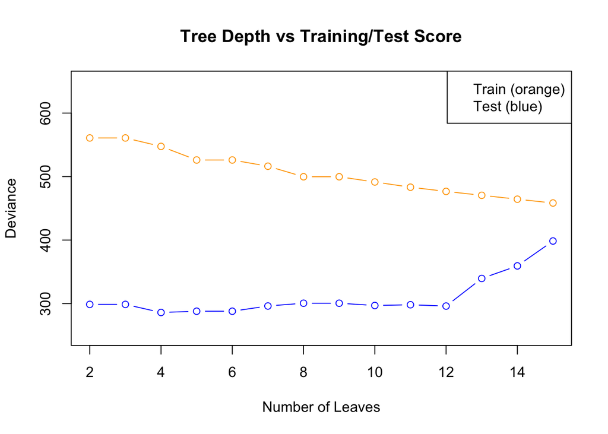

### 1.3.3 Optimal Tree

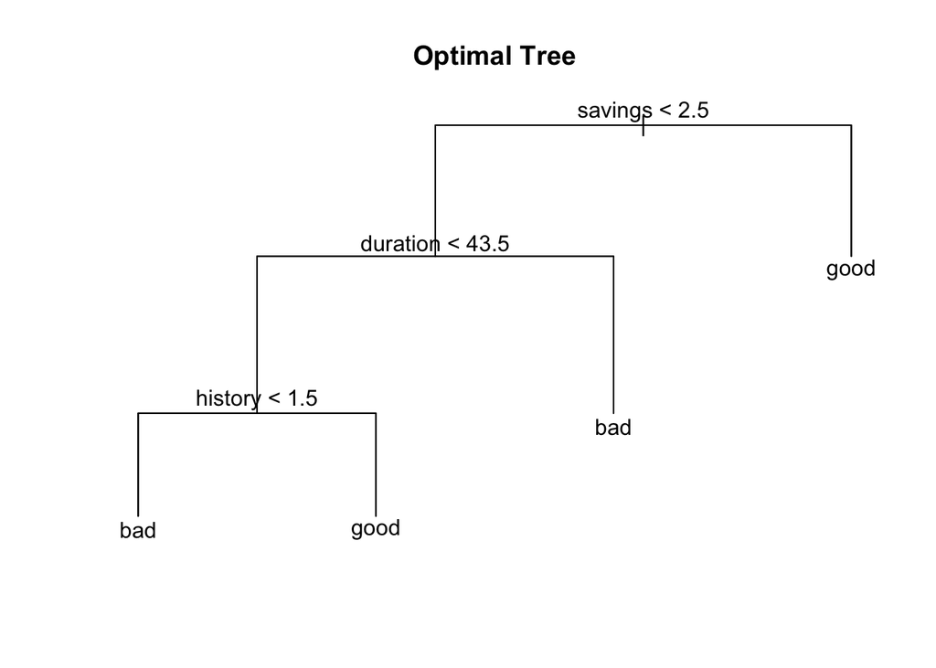

### 1.3.5 Estimate of the Missclassification Rate

```
##
## Classification tree:
## snip.tree(tree = decisionTree_deviance, nodes = c(5L, 3L, 9L))
## Variables actually used in tree construction:
## [1] "savings"  "duration" "history"
## Number of terminal nodes:  4
## Residual mean deviance:  1.117 = 547.5 / 490
## Misclassification error rate: 0.251 = 124 / 494
```

[output not shown]

```
## [1] 0.256
```

The last value shows the misclassification error on the test data set.

## 1.4 Naive Bayes

**Task:**

- Use training data to perform classification using Naive Bayes.
- Report the confusion matrices and misclassification rates for the training and for the test data.
- Compare the results with those from step 3.

### 1.4.1 Classification with Naive Bayes

Let’s train the model and have a look at the summary.

```
##         Length Class  Mode
## apriori  2     table  numeric
## tables  19     -none- list
## levels   2     -none- character
## call     4     -none- call
```

### 1.4.2 Naive Bayes Confusion Matrices and Misclassification Rates

Data for Naive Bayes on train:

|  | bad | good |
| --- | --- | --- |
| bad | 95 | 98 |
| good | 52 | 255 |

```
## [1] 0.3
```

Data for Naive Bayes on test:

|  | bad | good |
| --- | --- | --- |
| bad | 46 | 49 |
| good | 30 | 125 |

```
## [1] 0.316
```

### 1.4.3 Comparison with Step 3

We can see that the misqualification rate for the optimized decision tree is better than the Naive Bayes approach. We have to keep in mind that we first had to find the best tree and thus spend more time optimizing the hyper parameters.

## 1.5 TPR, FPR and ROC Curves

**Task:** Compute the TPR and FPR values for the two models.

The corresponding values for FPR and TPR can be seen in the following table.

| fprs_tree | tprs_tree | fprs_bayes | tprs_bayes |
| --- | --- | --- | --- |
| 1.0000000 | 1.0000000 | 1.0000000 | 1.0000000 |
| 1.0000000 | 1.0000000 | 0.8421053 | 0.9712644 |
| 1.0000000 | 1.0000000 | 0.8026316 | 0.9367816 |
| 1.0000000 | 1.0000000 | 0.7631579 | 0.9252874 |
| 0.8684211 | 1.0000000 | 0.6842105 | 0.9022989 |
| 0.8684211 | 1.0000000 | 0.6184211 | 0.8793103 |
| 0.8684211 | 1.0000000 | 0.5394737 | 0.8218391 |
| 0.7631579 | 0.9655172 | 0.5131579 | 0.7988506 |
| 0.7631579 | 0.9655172 | 0.4868421 | 0.7586207 |
| 0.7631579 | 0.9655172 | 0.4342105 | 0.7356322 |
| 0.7631579 | 0.9655172 | 0.3947368 | 0.7183908 |
| 0.7631579 | 0.9655172 | 0.3684211 | 0.6954023 |
| 0.7631579 | 0.9655172 | 0.3289474 | 0.6379310 |
| 0.7631579 | 0.9655172 | 0.2894737 | 0.6034483 |
| 0.7631579 | 0.9655172 | 0.2236842 | 0.5517241 |
| 0.1710526 | 0.3908046 | 0.2105263 | 0.5114943 |
| 0.1710526 | 0.3908046 | 0.1710526 | 0.4425287 |
| 0.0000000 | 0.0000000 | 0.1315789 | 0.3793103 |
| 0.0000000 | 0.0000000 | 0.0657895 | 0.3045977 |
| 0.0000000 | 0.0000000 | 0.0263158 | 0.2068966 |
| 0.0000000 | 0.0000000 | 0.0000000 | 0.0000000 |

**Task:** Plot the corresponding ROC curves.

This is the ROC curve of the Optimized Tree and Naive Bayes.

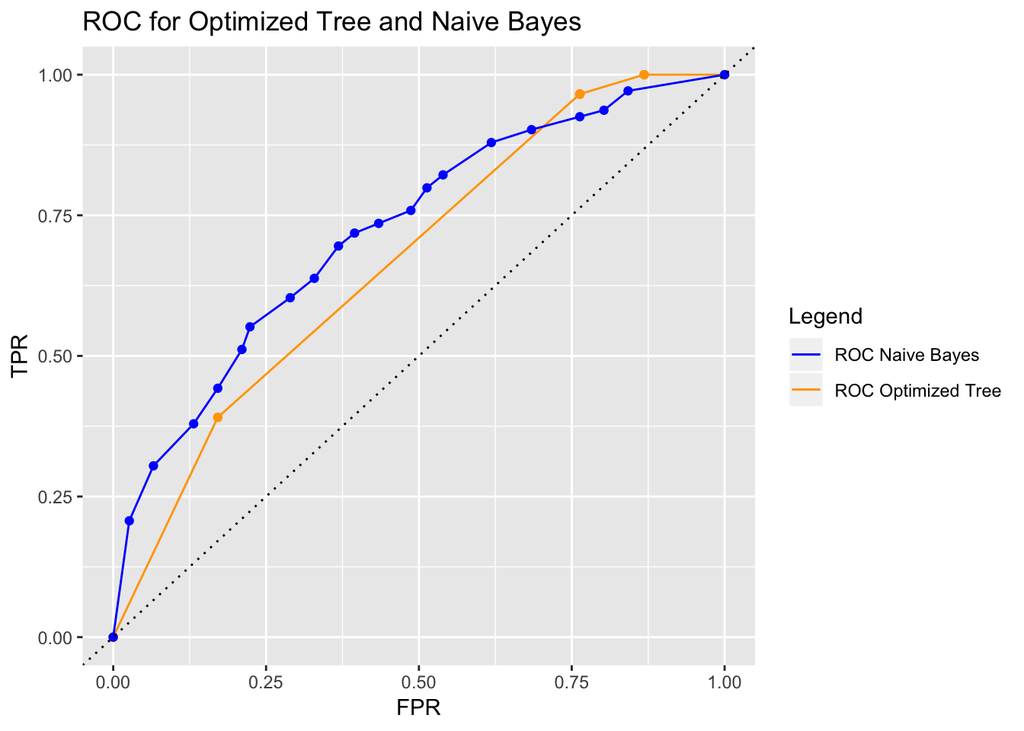

**Question:** Conclusion?

**Answer:** The ROC (receiver operating characteristic) curve shows how the models behaves for different threshold values. The greater the area under the curve the better the model can distinguish between two classes. This is due to the fact that we have overlapping distributions, which in worst case, are exactly on top of each other, which would result in a line at the 45 degree angle. As the distributations shift apart, our models will get better on average. Here we can observe, that the Naive Bayes is in general better in distinguishing the two classes, the Optimized Tree mostly performs worse. We have to keep in mind that we have few datapoints for small FPR for the tree and that we’ve not spent any effort interpolating the line between those two points.

## 1.6 Naive Bayes Classification with Loss Matrix

**Task:**

- Repeat Naive Bayes classification as it was in step 4 but use the following loss matrix.
- Report the confusion matrix for the training and test data.
- Compare the results with the results from step 4 and discuss how the rates has changed and why.

This is the given loss matrix:

|  | Predicted | Predicted |
| --- | --- | --- |
| good | 0 | 1 |
| bad | 10 | 0 |

Confusion Matrix for Training:

|  | bad | good |
| --- | --- | --- |
| FALSE | 137 | 263 |
| TRUE | 10 | 90 |

```
## [1] 0.546
```

Confusion Matrix for Test:

|  | bad | good |
| --- | --- | --- |
| FALSE | 71 | 122 |
| TRUE | 5 | 52 |

```
## [1] 0.508
```

# 2 Assignment 3: Uncertainty Estimation

## 2.1 Import and Plot `State.csv`

**Task:**

- Reorder your data with respect to the increase of MET and plot EX versus MET.
- Discuss what kind of model can be appropriate here.

Let’s import the data and have a look at it:

State.csv

| EX | ECAB | MET | GROW | YOUNG | OLD | WEST | STATE |
| --- | --- | --- | --- | --- | --- | --- | --- |
| 256 | 85.5 | 19.7 | 6.9 | 29.6 | 11.0 | 0 | ME |
| 275 | 94.3 | 17.7 | 14.7 | 26.4 | 11.2 | 0 | NH |
| 327 | 87.0 | 0.0 | 3.7 | 28.5 | 11.2 | 0 | VT |
| 297 | 107.5 | 85.2 | 10.2 | 25.1 | 11.1 | 0 | MA |
| 256 | 94.9 | 86.2 | 1.0 | 25.3 | 10.4 | 0 | RI |
| 312 | 121.6 | 77.6 | 25.4 | 25.2 | 9.6 | 0 | CT |

Let’s plot the data:

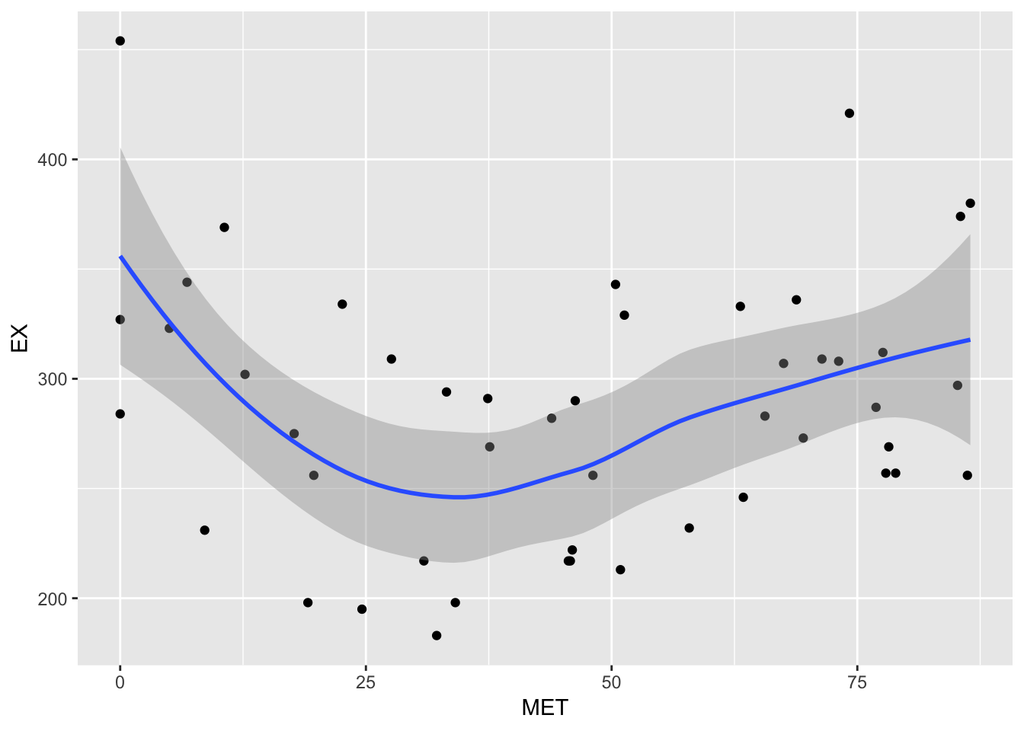

At a first glance this data looks messy, but taking a second look gives the impression that the data has different kind of levels. Therefor a Regression Tree would probably be a good model.

## 2.2 Regression Tree Model

**Task:**

- Report the selected tree.
- Plot the original and the fitted data and histogram of residuals.
- Comment on the distribution of the residuals and the quality of the fit.

Let’s create a Regression Tree Model and use Cross Validation to see which sizes is the best.

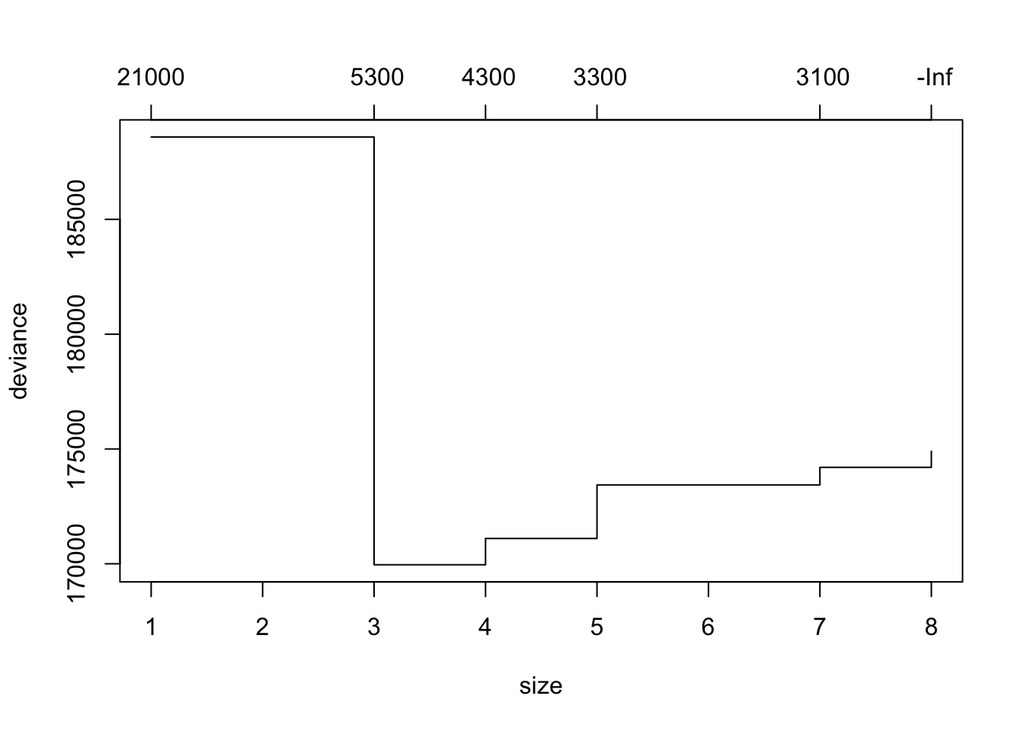

We see that 3 or 4 would work for the size of the tree. For the following we will declare `best = 3`. Let’s prune our best tree and have a look at it.

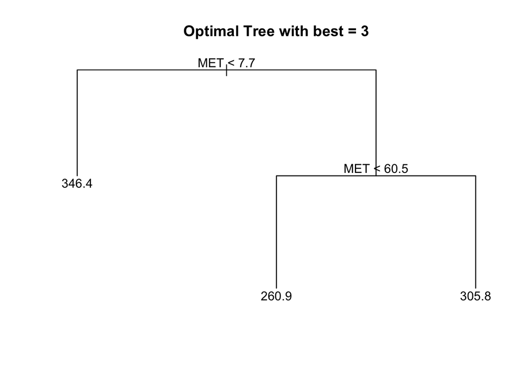

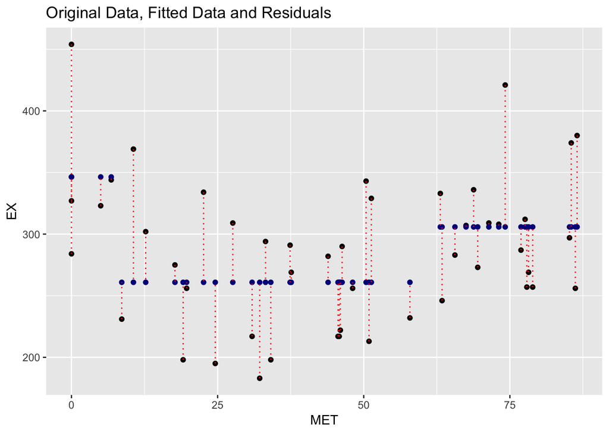

And here we have the histrogram of the residuals.

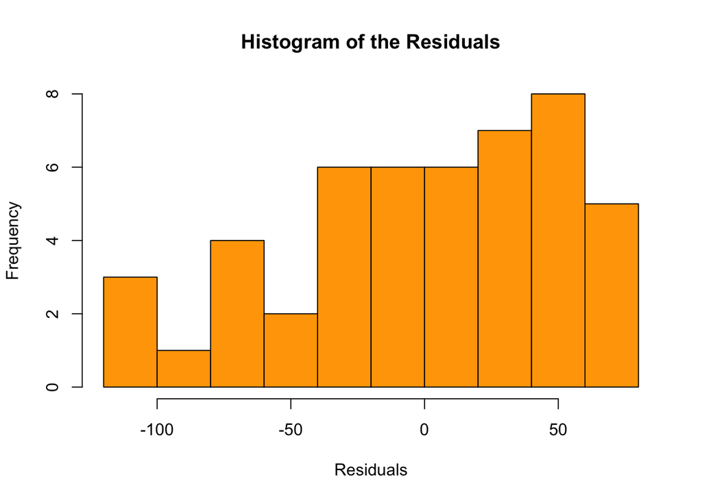

## 2.3 Confidence Bands (non-parametric)

**Task:**

- Compute and plot the 95% confidence bands for the regression tree model from step 2 by using a non-parametric bootstrap.
- Comment whether the band is smooth or bumpy and try to explain why.
- Consider the width of the confidence band and comment whether results of the regression model in step 2 seem to be reliable.

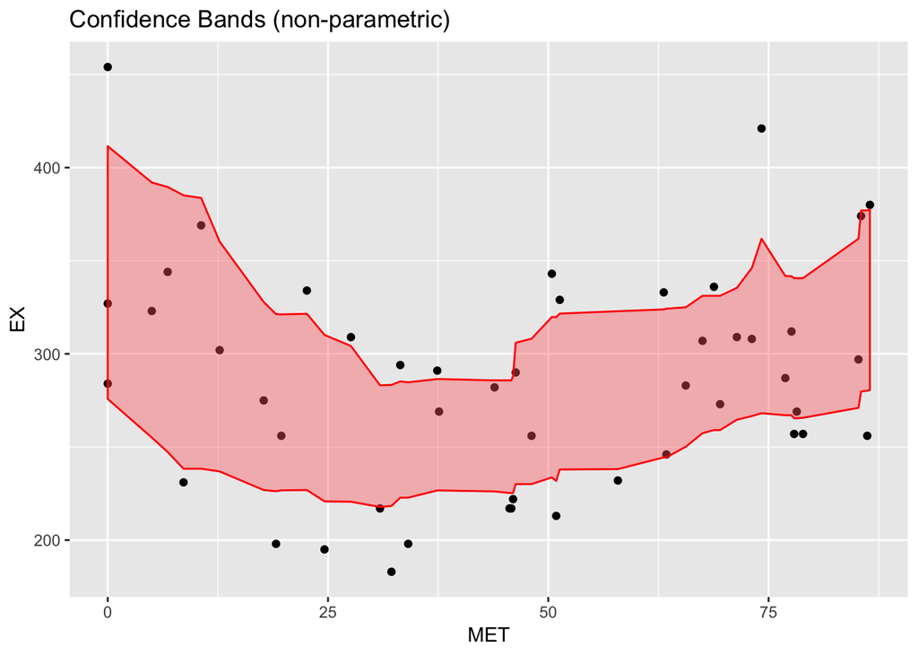

## 2.4 Confidence Bands (parametric)

**Task:**

- Compute and plot the 95% confidence and prediction bands the regression tree model from step 2 by using a parametric bootstrap.
- Consider the width of the confidence band and comment whether results of the regression model in step 2 seem to be reliable. Does it look like only 5% of data are outside the prediction band? Should it be?

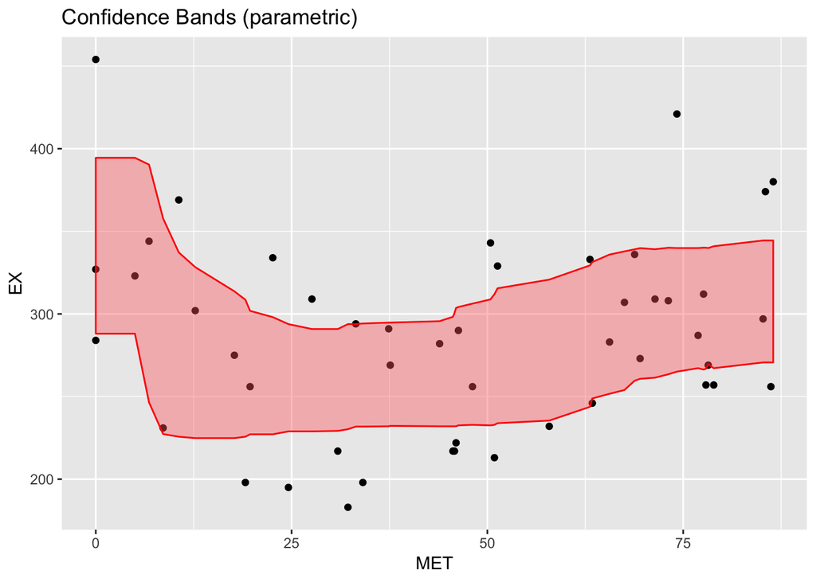

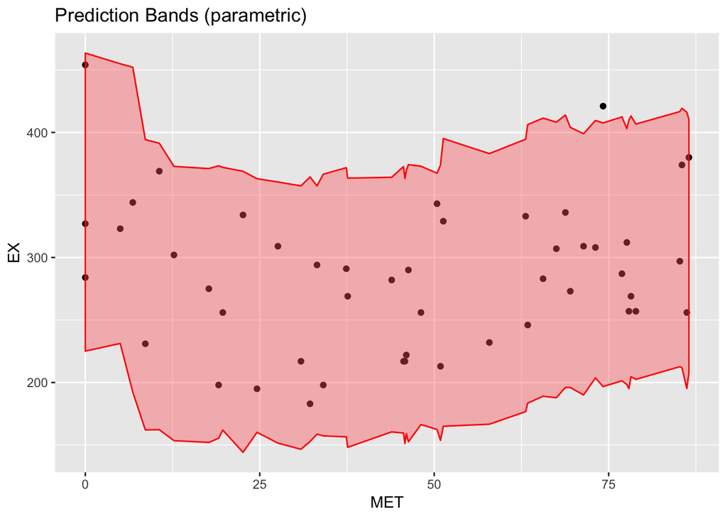

**Comment:** The confidence intervall is shallow. It is showing us, for which original data points we have a confidence of 95% that we classified is correctly, which makes sense, as we used the tree generated previously as a statistic. For the prediction band we can see that basically just one data point is not inside of the band. We have therefor 1 out of 48 datapoints outside of our prediction band, which is around 2.1%. I’d have expected it to be two or three, but I think one is still feasible.

## 2.5 Conclusions

**Task:** Consider the histogram of residuals from step 2 and suggest what kind of bootstrap is actually more appropriate here.

# 3 Assignemnt 4: Principal Components

## 3.1 Principal Component Analysis

**Task:**

- Conduct a standard PCA by using the feature space and provide a plot explaining how much variation is explained by each feature.
- Does the plot show how many PC should be extracted?
- Select the minimal number of components explaining at least 99% of the total variance.
- Provide also a plot of the scores in the coordinates (PC1, PC2).
- Are there unusual diesel fuels according to this plot?

Let’s import the data and have a look at it.

[output not shown]

Variance for each Feature

| x |
| --- |
| 93.332 |
| 6.263 |
| 0.185 |
| 0.101 |
| 0.068 |
| 0.025 |

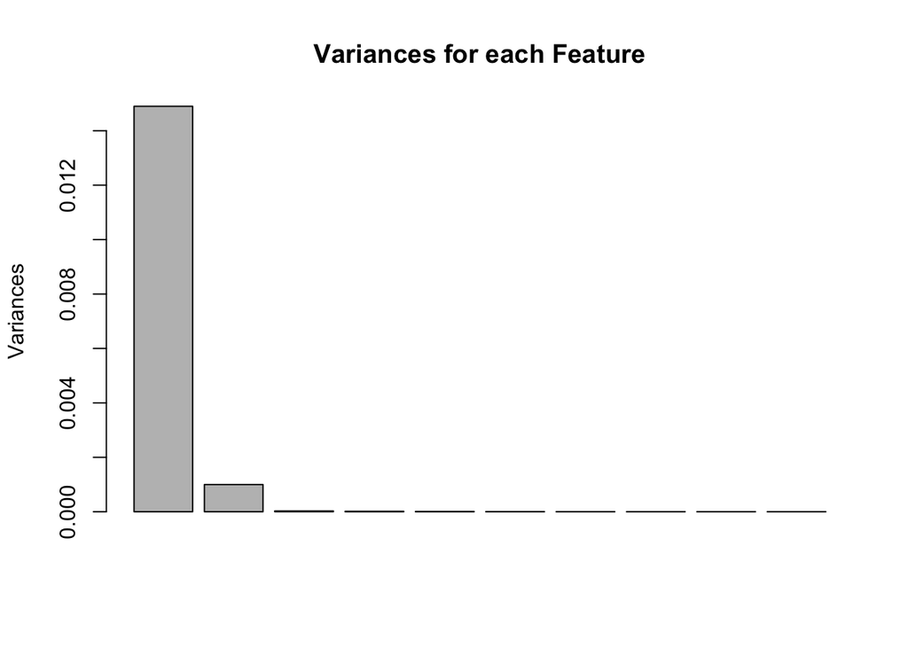

As we can see from the plot and the table, the first feature is responsible for `93.332%` of the variance and the second feature for `6.262%`. Together those two make of of `99.594%` of the variance.

Let’s have a look at the plot for PC1 and PC2.

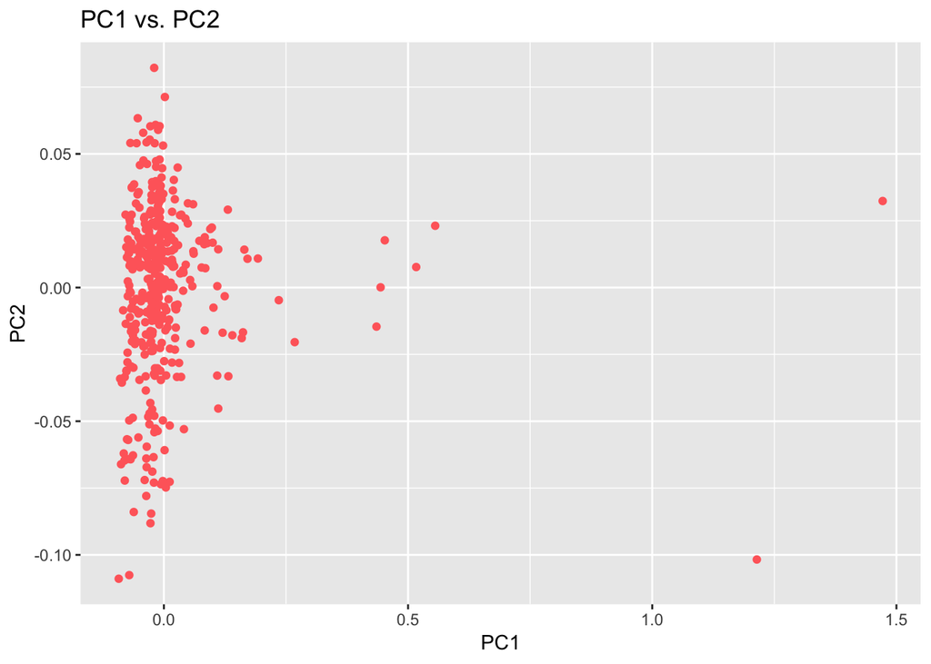

We can see that there are some datapoints which are far away from the others, but just two of them are really far away, their PC1 values are greater than `1.0`, even nearly around `1.5` for one.

## 3.2 Trace Plots

**Task:** Make trace plots of the loadings of the components selected in step 1. Is there any principle component that is explained by mainly a few original features?

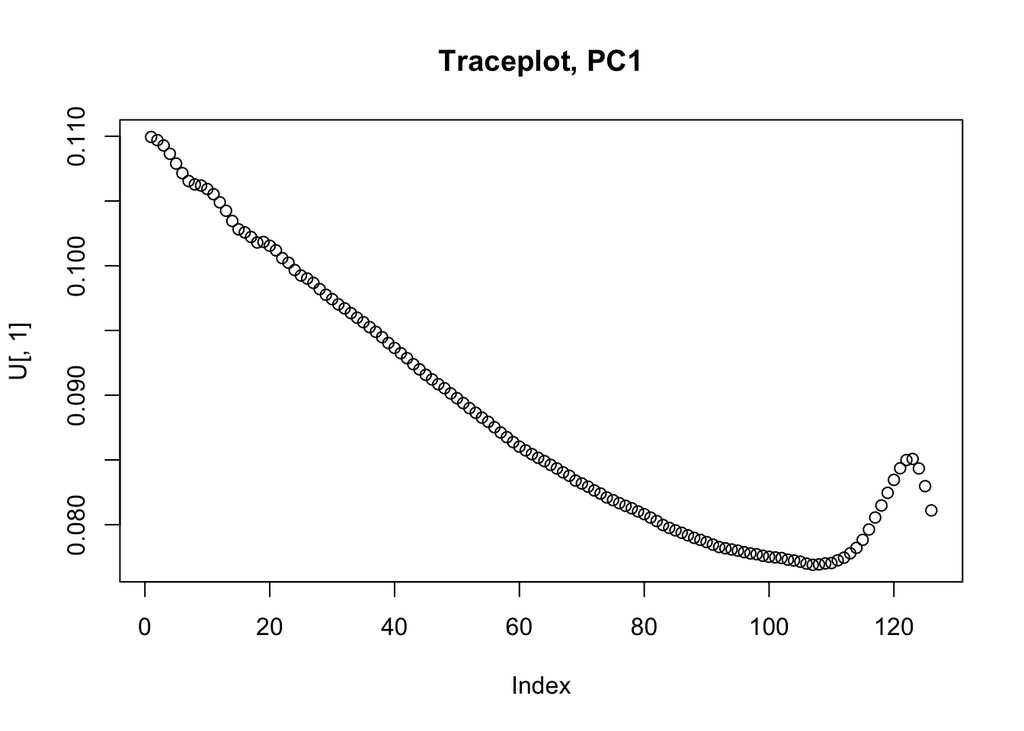

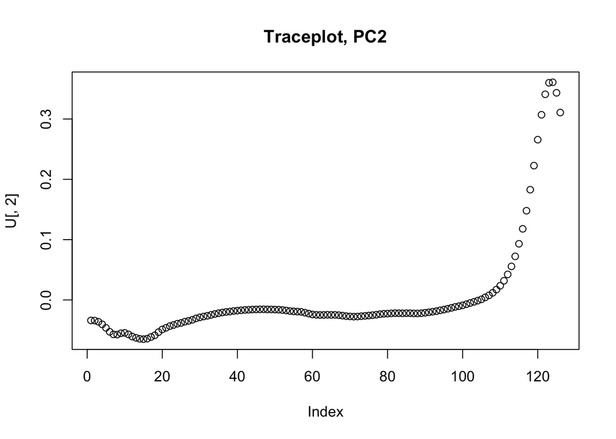

## 3.3 ICA

- Perform Independent Component Analysis with the number of components selected in step 1.
- Compute W’ = K * W
- Present the columns of W’ in form of the trace plots.
- Compare with the trace plots in step 2 and make conclusions. What kind of measure is represented by the matrix W’?
- Make a plot of the scores of the first two latent features and compare it with the score plot from step 1.

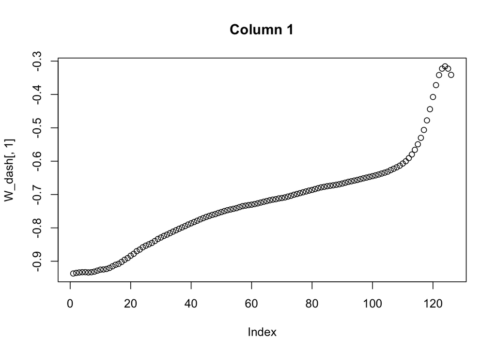

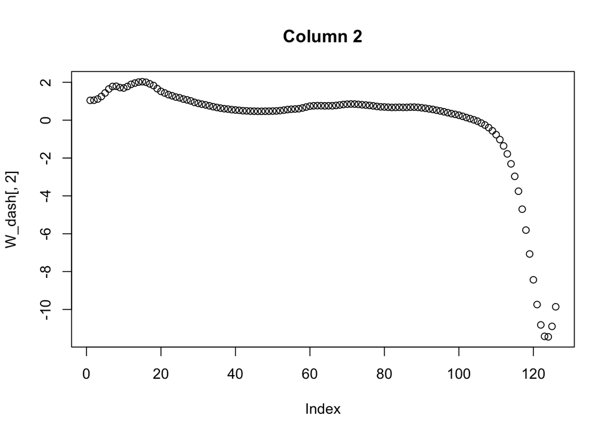

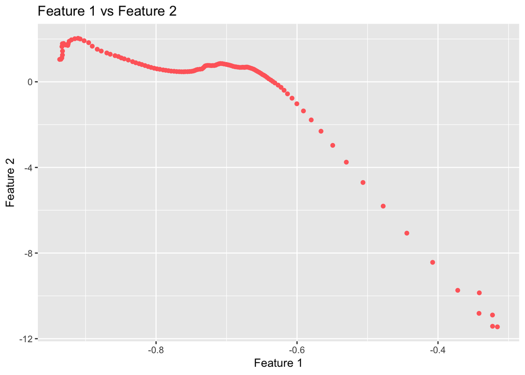

# 4 Appendix: Source Code

```r
knitr::opts_chunk$set(echo = TRUE)
library(knitr)
library(ggplot2)
library(readxl)
library(tree)
library(e1071)
library(boot)
library(fastICA)

################################################################################
# Assignment 2: Analysis of Credit Scoring
################################################################################

set.seed(12345)
creditscoring = read_excel("./creditscoring.xls")
creditscoring$good_bad = as.factor(creditscoring$good_bad)
kable(head(creditscoring[,(ncol(creditscoring)-10):ncol(creditscoring)]),
      caption = "creditscoring.xls")


n=dim(creditscoring)[1]
set.seed(12345)
id=sample(1:n, floor(n*0.5))
train=creditscoring[id,]

id1=setdiff(1:n, id)
set.seed(12345)
id2=sample(id1, floor(n*0.25))

valid=creditscoring[id2,]
id3=setdiff(id1,id2)
test=creditscoring[id3,]


# Create the models
decisionTree_deviance = tree(good_bad ~ ., data = train, split = "deviance")
decisionTree_gini = tree(good_bad ~ ., data = train, split = "gini")


# Prediction
prediction_deviance_train =
  predict(decisionTree_deviance, newdata = train, type = "class")
prediction_deviance_test =
  predict(decisionTree_deviance, newdata = test, type = "class")

predictiona_gini_train =
  predict(decisionTree_gini, newdata = train, type = "class")
prediction_gini_test =
  predict(decisionTree_gini, newdata = test, type = "class")


summary(decisionTree_deviance)
#plot(decisionTree_deviance)


confusion_matrix_deviance = table(prediction_deviance_test, test$good_bad)
kable(confusion_matrix_deviance)


error_rate_deviance =
  1 - sum(diag(confusion_matrix_deviance)/sum(confusion_matrix_deviance))
print(error_rate_deviance)


summary(decisionTree_gini)
#plot(decisionTree_gini)


confusion_matrix_gini = table(prediction_gini_test, test$good_bad)
kable(confusion_matrix_gini)


error_rate_gini =
  1 - sum(diag(confusion_matrix_gini)/sum(confusion_matrix_gini))
print(error_rate_gini)


# Taken from the slides
trainScore = rep(0, 15)
testScore = rep(0, 15)

for(i in 2:15) {
  prunedTree = prune.tree(decisionTree_deviance, best = i)
  pred = predict(prunedTree, newdata = valid, type = "tree")
  trainScore[i] = deviance(prunedTree)
  testScore[i] = deviance(pred)
}


## Add one as we trim the first index
optimalTreeIdx = which.min(testScore[-1]) + 1
optimalTreeScore = min(testScore[-1])

print(optimalTreeIdx)
print(optimalTreeScore)


plot(2:15, trainScore[2:15], type = "b", col = "orange", ylim = c(250,650),
     main = "Tree Depth vs Training/Test Score", ylab = "Deviance",
     xlab = "Number of Leaves")
points(2:15, testScore[2:15], type = "b", col = "blue")
legend("topright", legend = c("Train (orange)", "Test (blue)"))


optimalTree = prune.tree(decisionTree_deviance, best = optimalTreeIdx)
plot(optimalTree)
text(optimalTree, pretty = 1)
title("Optimal Tree")


prediction_optimalTree_test =
  predict(optimalTree, newdata = test, type = "class")

confusion_matrix_optimalTree = table(prediction_optimalTree_test, test$good_bad)

error_optimalTree =
  1 - sum(diag(confusion_matrix_optimalTree)/sum(confusion_matrix_optimalTree))


summary(optimalTree)
kable(confusion_matrix_gini)
print(error_optimalTree)


naiveBayesModel = naiveBayes(good_bad ~ ., data = train)
summary(naiveBayesModel)


# Prediction
prediction_bayes_train =
  predict(naiveBayesModel, newdata = train, type = "class")
prediction_bayes_test =
  predict(naiveBayesModel, newdata = test, type = "class")

confusion_matrix_bayes_train = table(prediction_bayes_train, train$good_bad)
confusion_matrix_bayes_test = table(prediction_bayes_test, test$good_bad)

error_bayes_train = 1 - sum(diag(confusion_matrix_bayes_train)/
                              sum(confusion_matrix_bayes_train))
error_bayes_test =  1 - sum(diag(confusion_matrix_bayes_test)/
                              sum(confusion_matrix_bayes_test))


kable(confusion_matrix_bayes_train)
print(error_bayes_train)


kable(confusion_matrix_bayes_test)
print(error_bayes_test)


# prediction optimal tree
prediction_optimalTree_test_p =
  predict(optimalTree, newdata = test, type = "vector")
# prediction naive bayes
prediction_bayes_test_p =
  predict(naiveBayesModel, newdata = test, type = "raw")

pi = seq(from = 0.00, to = 1.0, by = 0.05)
fprs_tree = c()
tprs_tree = c()
fprs_bayes = c()
tprs_bayes = c()

for (i in pi) {
  current_tree_pi_confusion =
    table(test$good_bad, factor(prediction_optimalTree_test_p[,2] > i,
                                lev=c(TRUE, FALSE)))
  current_bayes_pi_confusion =
    table(test$good_bad, factor(prediction_bayes_test_p[,2] > i,
                                lev=c(TRUE, FALSE)))

  # FPR = FP / N-
  # TPR = TP / N+
  fprs_tree = c(fprs_tree, current_tree_pi_confusion[1,1]/
                 sum(current_tree_pi_confusion[1,]))
  tprs_tree = c(tprs_tree, current_tree_pi_confusion[2,1]/
                  sum(current_tree_pi_confusion[2,]))

  fprs_bayes = c(fprs_bayes, current_bayes_pi_confusion[1,1]/
                   sum(current_bayes_pi_confusion[1,]))
  tprs_bayes = c(tprs_bayes, current_bayes_pi_confusion[2,1]/
                   sum(current_bayes_pi_confusion[2,]))
}

roc_values = data.frame(fprs_tree, tprs_tree, fprs_bayes, tprs_bayes)


kable(roc_values)


ggplot(roc_values) +
  geom_line(aes(x = fprs_tree, y = tprs_tree,
                colour = "ROC Optimized Tree")) +
  geom_point(aes(x = fprs_tree, y = tprs_tree), colour = "orange") +

  geom_line(aes(x = fprs_bayes, y = tprs_bayes,
                colour = "ROC Naive Bayes")) +
  geom_point(aes(x = fprs_bayes, y = tprs_bayes), colour = "blue") +

  geom_abline(slope=1, intercept=0, linetype="dotted") +

  labs(title = "ROC for Optimized Tree and Naive Bayes", y = "TPR",
       x = "FPR", color = "Legend") +
  scale_color_manual(values = c("blue", "orange"))


L = matrix(c(0, 10, 1, 0), nrow = 2)
colnames(L) = c("Predicted", "Predicted")
rownames(L) = c("good", "bad")
kable(L)


# Prediction
prediction_bayes_train_raw =
  predict(naiveBayesModel, newdata = train, type = "raw")
prediction_bayes_test_raw =
  predict(naiveBayesModel, newdata = test, type = "raw")
```

```r
confusion_matrix_bayes_train =
  table(prediction_bayes_train_raw[,2]/
          prediction_bayes_train_raw[,1] > 10, train$good_bad)
confusion_matrix_bayes_test =
  table(prediction_bayes_test_raw[,2]/
          prediction_bayes_test_raw[,1] > 10, test$good_bad)

error_bayes_train_raw = 1 - sum(diag(confusion_matrix_bayes_train)/
                              sum(confusion_matrix_bayes_train))
error_bayes_test_raw =  1 - sum(diag(confusion_matrix_bayes_test)/
                              sum(confusion_matrix_bayes_test))

kable(confusion_matrix_bayes_train)
print(error_bayes_train_raw)


kable(confusion_matrix_bayes_test)
print(error_bayes_test_raw)


################################################################################
# Assignment 3: Uncertainty Estimation
################################################################################

statedata = read.csv("./State.csv", sep = ";", dec = ",")
kable(head(statedata),  caption = "State.csv")


statedata$MET = as.numeric(statedata$MET)
statedata = statedata[order(statedata$MET),]
ggplot(statedata, aes(x = MET, y = EX)) +  geom_point() + geom_smooth()


# Create the model
reg_tree = tree(EX ~ MET, data = statedata, control =
                  tree.control(nobs = nrow(statedata), minsize = 8))

# Use cross validation
cross_val_reg_tree = cv.tree(reg_tree)

# Plot the deviance of the sizes
plot(cross_val_reg_tree)


# Let's create the pruned the with best set to 3 and get it's prediction
pruned_tree = prune.tree(reg_tree, best = 3)
pruned_tree_prediction = predict(pruned_tree, newdata = statedata, type = "vector")

# We create a data.frame to save our values to make it easier to plot the data
pruned_tree_plot_dataframe =
  data.frame(statedata$MET, statedata$EX, pruned_tree_prediction,
             pruned_tree_prediction-statedata$EX)
names(pruned_tree_plot_dataframe) = c("met", "orignal_ex", "predicted_ex", "residual")

# Lets first plot the pruned tree
plot(pruned_tree)
text(pruned_tree, pretty = 1)
title("Optimal Tree with best = 3")

# Lets create a plot with the real and predictes values and highlight the
# residuals
ggplot(pruned_tree_plot_dataframe) +
  geom_point(aes(x = pruned_tree_plot_dataframe$met,
                 y = pruned_tree_plot_dataframe$orignal_ex),
             color = "black") +
  geom_point(aes(x = pruned_tree_plot_dataframe$met,
                 y = pruned_tree_plot_dataframe$predicted_ex),
             color = "darkblue") +
  geom_segment(mapping=aes(x=pruned_tree_plot_dataframe$met,
                           y=pruned_tree_plot_dataframe$orignal_ex,
                           xend=pruned_tree_plot_dataframe$met,
                           yend=pruned_tree_plot_dataframe$predicted_ex),
               color = "red", linetype = "dotted") +
  labs(title = "Original Data, Fitted Data and Residuals", y = "EX",
       x = "MET", color = "Legend")


hist(pruned_tree_plot_dataframe$residual,
     col="orange", main = "Histogram of the Residuals", xlab = "Residuals")


# We take the function given from the slides and adjust to the tree
# computing bootstrap samples
f_non_p_bootstrap = function(data, ind) {

  # First take the subsample
  data1 = data[ind,]

  # Now create a tree with the same hyperparameters from that subsample
  tree_model = tree(EX ~ MET, data = data1,
                    control = tree.control(nrow(data),minsize = 8))
  tree_model_pruned = prune.tree(tree_model, best = 3)

  # Use that model to predict on the real data
  prediction = predict(tree_model_pruned, newdata = data)
  return(prediction)
}

# Lets create the Bootstrap (again taken from slides)
res = boot(statedata, f_non_p_bootstrap, R = 1000)

# Confidence Bands using envelope
ci_non_p_bootstrap = envelope(res)
ci_non_p_bootstrap_df = as.data.frame(t(ci_non_p_bootstrap$point))
names(ci_non_p_bootstrap_df) = c("upper_bound", "lower_bound")
pruned_tree_plot_dataframe =
  data.frame(pruned_tree_plot_dataframe, ci_non_p_bootstrap_df)

# Plot the data
ggplot(pruned_tree_plot_dataframe) +
  geom_point(aes(x = pruned_tree_plot_dataframe$met,
                 y = pruned_tree_plot_dataframe$orignal_ex),
             color = "black") +
  geom_ribbon(aes(x = pruned_tree_plot_dataframe$met,
                  ymin = ci_non_p_bootstrap_df$lower_bound,
                  ymax = ci_non_p_bootstrap_df$upper_bound),
              alpha = 0.4, fill = "indianred1", color = "red") +
    labs(title = "Confidence Bands (non-parametric)", y = "EX",
       x = "MET", color = "Legend")


# Again we take the sample from the slides and adjust it to our needs
# 1) Compute value mle
# 2) Write function ran.gen that depends on data and mle and which generates
# new data
# 3) Write function statistic that depend on data which will be generated by
# ran.gen and should return the estimator

## 1)
mle = pruned_tree

## 2)
rng = function(data, mle) {
  data1 = data.frame(EX=data$EX, MET=data$MET)
  n = length(data$EX)
  #generate new Price
  # summary needed to access the residuals
  data1$EX = rnorm(n, predict(mle, newdata=data1), sd(summary(mle)$residuals))
  return(data1)
}

## 3) f_non_p_bootstrap + distribution N
f_p_bootstrap = function(data) {

  # The index is not needed any more as we don't take a sub-sample

  # Now create a tree with the same hyperparameters from that subsample
  tree_model = tree(EX ~ MET, data = data,
                    control = tree.control(nrow(data), minsize = 8))
  tree_model_pruned = prune.tree(tree_model, best = 3)

  # Use that model to predict on the real data
  prediction = predict(tree_model_pruned, newdata = data)

  return(prediction)
}

# Bootstrap
res2 = boot(statedata,
            statistic = f_p_bootstrap, R=1000, mle=mle,
            ran.gen=rng, sim="parametric")

# Confidence Bands using envolope
ci_p_bootstrap = envelope(res2)
ci_p_bootstrap_df = as.data.frame(t(ci_p_bootstrap$point))
names(ci_p_bootstrap_df) = c("upper_bound", "lower_bound")
pruned_tree_plot_dataframe_p =
  data.frame(pruned_tree_plot_dataframe, ci_p_bootstrap_df)
```

```r
# Plot the data
ggplot(pruned_tree_plot_dataframe_p) +
  geom_point(aes(x = pruned_tree_plot_dataframe_p$met,
                 y = pruned_tree_plot_dataframe_p$orignal_ex),
             color = "black") +
  geom_ribbon(aes(x = pruned_tree_plot_dataframe_p$met,
                  ymin = ci_p_bootstrap_df$lower_bound,
                  ymax = ci_p_bootstrap_df$upper_bound),
              alpha = 0.4, fill = "indianred1", color = "red") +
    labs(title = "Confidence Bands (parametric)", y = "EX",
       x = "MET", color = "Legend")


# Prediction Bands

# from slides
f_p_bootstrap_pb = function(data) {

  # The index is not needed any more as we don't take a sub-sample

  # Now create a tree with the same hyperparameters from that subsample
  tree_model = tree(EX ~ MET, data = data,
                    control = tree.control(nrow(data), minsize = 8))
  tree_model_pruned = prune.tree(tree_model, best = 3)

  # Use that model to predict on the real data
  prediction = predict(tree_model_pruned, newdata = data)

  # Add the rnrom to the prediction
  prediction_normal = rnorm(nrow(data), prediction, sd(summary(mle)$residual))

  return(prediction_normal)
}

# Bootstrap
res3 = boot(statedata, statistic = f_p_bootstrap_pb,
            R=1000, mle=mle, ran.gen=rng, sim="parametric")

# Confidence Bands using envolope
pb_p_bootstrap = envelope(res3)
pb_p_bootstrap_df = as.data.frame(t(pb_p_bootstrap$point))
names(pb_p_bootstrap_df) = c("upper_bound", "lower_bound")
pruned_tree_plot_dataframe_p_pb =
  data.frame(pruned_tree_plot_dataframe, pb_p_bootstrap_df)

# Plot the data
ggplot(pruned_tree_plot_dataframe_p_pb) +
  geom_point(aes(x = pruned_tree_plot_dataframe_p_pb$met,
                 y = pruned_tree_plot_dataframe_p_pb$orignal_ex),
             color = "black") +
  geom_ribbon(aes(x = pruned_tree_plot_dataframe_p_pb$met,
                  ymin = pb_p_bootstrap_df$lower_bound,
                  ymax = pb_p_bootstrap_df$upper_bound), alpha = 0.4,
              fill = "indianred1", color = "red") +
    labs(title = "Prediction Bands (parametric)", y = "EX",
       x = "MET", color = "Legend")


################################################################################
# Assignment 4: Principal Components
################################################################################

set.seed(12345)
nir_spectra = read.csv2("./NIRspectra.csv")
kable(head(statedata),  caption = "NIRspectra.csv")


# Copy to not modify the original dataset
nir_spectra_copy = nir_spectra
nir_spectra_copy$Viscosity = c()

# PCA
res = prcomp(nir_spectra_copy)

# Eigenvalues
lambda = res$sdev^2

# Proportion of variation
kable(head(sprintf("%2.3f",lambda/sum(lambda)*100)), caption = "Variance for each Feature")

# Plot
screeplot(res, main = "Variances for each Feature")


ggplot(as.data.frame(res$x)) +
  geom_point(aes(x = res$x[,1],
                 y = res$x[,2]),
             color = "indianred1") +
    labs(title = "PC1 vs. PC2", y = "PC2",
       x = "PC1", color = "Legend")


U = res$rotation
plot(U[,1], main = "Traceplot, PC1")
plot(U[,2], main = "Traceplot, PC2")


set.seed(12345)

ica_model = fastICA(X = nir_spectra_copy, n.comp = 2, alg.typ = "parallel",
                    fun = "logcosh", alpha = 1, method = "R", row.norm = FALSE,
                    maxit = 200, tol = 0.0001, verbose = FALSE)

W_dash = ica_model$K %*% ica_model$W

plot(W_dash[,1], main= "Column 1")
plot(W_dash[,2], main= "Column 2")

ggplot(as.data.frame(W_dash)) +
  geom_point(aes(x = W_dash[,1],
                 y = W_dash[,2]),
             color = "indianred1") +
    labs(title = "Feature 1 vs Feature 2", y = "Feature 2",
       x = "Feature 1", color = "Legend")
```